# Talent Management

Mai Loan Tran, Zackary Gill

December 8, 2018

## Executive Summary

#### Talent management is an iterative process of developing and retaining employees. Our analysis yielded ten (10) factors that contribute to turnover with an overall 87.3% accuracy. While there were positive relationships between the varying satisfaction metrics recently collected by job roles, the differences were not statistically significant. The final model was constructed using logistic regression although we also explored K Nearest Neighbor as an alternative model.

## Introduction

#### DDSAnalytics is tasked with predicting employee turnover by conducting an analysis of employee data for the purpose of talent management. While seeking to determine factors that lead to attrition and identify job role specific trends, our deliverable is to build a model to predict attrition with at least 60% accuracy.

```r
library(caret)
library(MASS)
library(lattice)
library(ggplot2)
library(dplyr)
library(onewaytests)
library(agricolae)
#library(class)
#library(mlr)

#Reads in the files
dfTrain <- read.csv("csv/CaseStudy2-data.csv")
dfVal <- read.csv("csv/CaseStudy2Validation.csv")
```

## Analysis

#### We began our data analysis by plotting all the variables [Chart 1] to identify the correlation and direction of the relationship between the pairs of variables. This was done in order to visually see if any one factor heavily contributed to Attrition. Below is a sample of the plotting done between Attrition and the other variables.

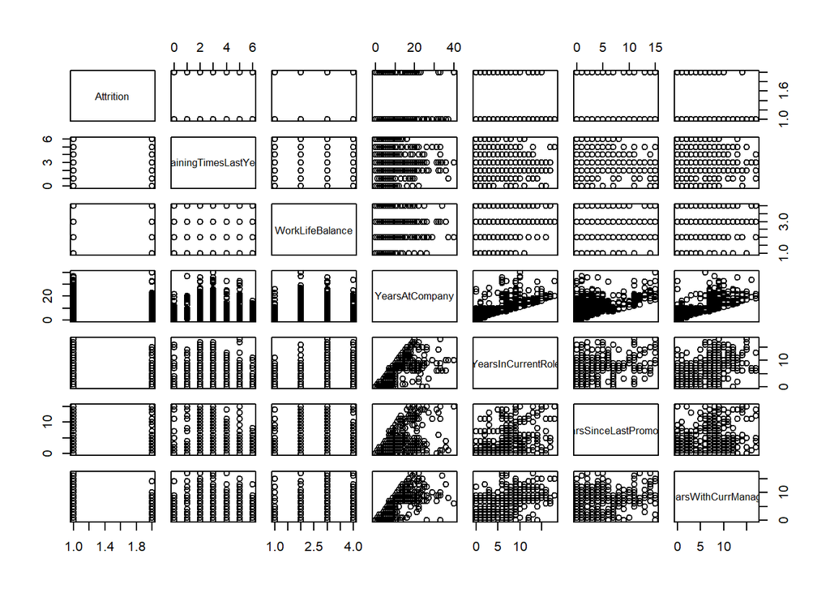

```r
#-------------Scatterplot matrices of all variables to identify correlations between pairs of variables within the data set-------------
#pairs(dfTrain[,c(3,2,4:8)])
#pairs(dfTrain[,c(3,9:16)])
#pairs(dfTrain[,c(3,17:23)])
#pairs(dfTrain[,c(3,24:30)])
pairs(dfTrain[,c(3,31:36)])
```

```r
#Back up the Over18 column for the future
Over18.test <- dfTrain$Over18
Over18.val <- dfVal$Over18

#Gets rid of variable with only 1 level
dfTrain$Over18 <- NULL
dfVal$Over18 <- NULL

#-------------------Analysis of Job Role Specific Trends--------------------
#Create function to calculate the amount into a percentage and process the transformation to a table and back
makereadyforplot <- function(df)
{
  df1 <- table(df)
  df2 <- df1
  for(i in c(1:length(df1[,1])))
  {
    for(j in c(1:4))
    {
      df2[i,j] <- round(100*df1[i,j]/(df1[i,1]+df1[i,2]+df1[i,3]+df1[i,4]),0)
    }
  }

  as.data.frame(df2)
}
```

`[Chart 1: Plotting Attrition vs Other Variables ...]`

#### Next we looked for the relationship between job role and the differing satisfaction metrics from the recent survey responses. For each of these we used Welch’s ANOVA and Fisher’s LSD (with Bonferroni correction).

#### While there was not a statistical significance in job satisfaction beteen the roles (p-value 0.9079), Research Scientists and Healthcare Representatives [Chart 2] both have the highest equal mean in job satisfaction at 2.80 in Medium-High range. Thirty-four percent (34%) of Research Scientists reported Very High job satisfaction whereas 35% of Healthcare Representatives reported the same. Human Resources have the lowest mean at 2.57 with 30% reporting High job satisfaction.

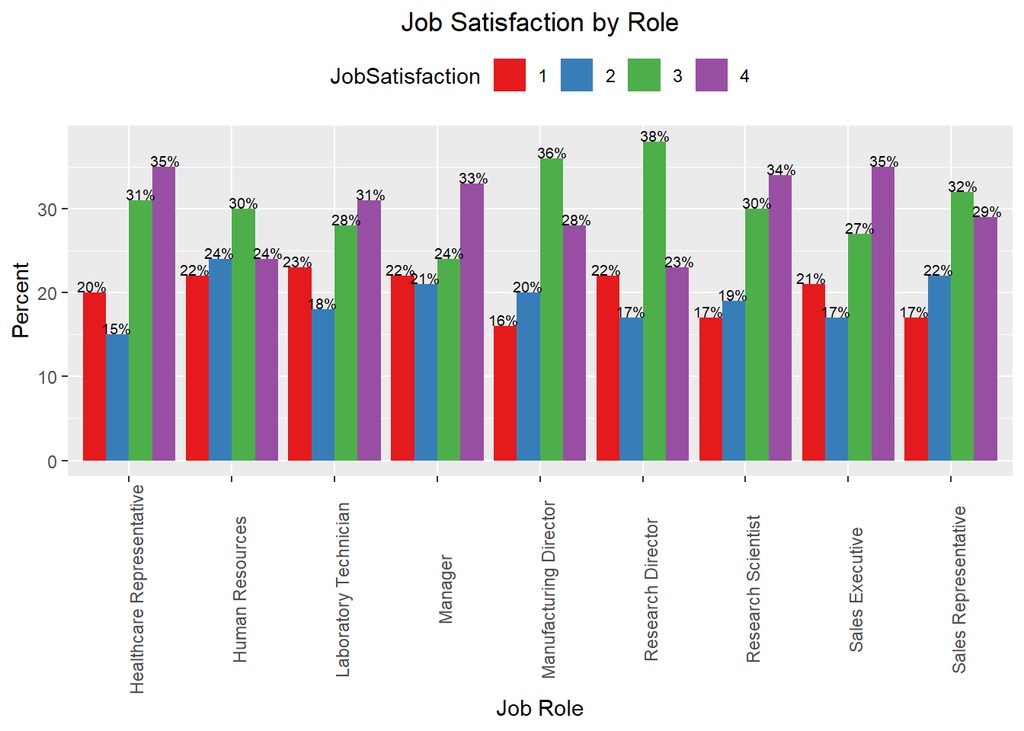

```r
#Gets only the rows we want and make sure they are always in the same order
dfTrain.js <- dfTrain[,c("JobRole","JobSatisfaction")]
dfTrain2 <- makereadyforplot(dfTrain.js)

#Plot Job Satisifaction by Role
ggplot(data = dfTrain2, aes(x = factor(JobRole), y=Freq, group=JobSatisfaction, fill = JobSatisfaction)) +
  geom_bar(stat = "identity", position = "dodge") +
  xlab("Job Role") +
  ylab("Percent") +
  geom_text(size=2.5, vjust=-0.1, aes(label= paste(Freq,"%",sep="")), position=position_dodge(width=0.95)) +
  scale_fill_brewer(palette = "Set1") +
  ggtitle("Job Satisfaction by Role") +
  theme(legend.position="top",plot.title = element_text(hjust = 0.5),axis.text.x = element_text(angle = 90))
```

```r
#Welch's ANOVA for Job Satisfaction
output.js.welch = welch.test(JobSatisfaction~JobRole,data=dfTrain.js)
```

```
  Welch's Heteroscedastic F Test
---------------------------------------------------------
  data : JobSatisfaction and JobRole

  statistic  : 0.4213531
  num df     : 8
  denom df   : 300.0874
  p.value    : 0.9078979

  Result     : Difference is not statistically significant.
---------------------------------------------------------
```

```r
#Fisher LSD with Bonferroni correction
aov.js = aov(JobSatisfaction~JobRole,data=dfTrain.js)
output.js.bon = LSD.test(aov.js,"JobRole", p.adj="bonferroni")
output.js.bon$groups
```

```
                          JobSatisfaction groups
Research Scientist               2.802521      a
Healthcare Representative        2.801980      a
Sales Executive                  2.755814      a
Manufacturing Director           2.750000      a
Sales Representative             2.738462      a
Manager                          2.692308      a
Laboratory Technician            2.685446      a
Research Director                2.625000      a
Human Resources                  2.567568      a
```

`[Chart 2: Job Satisfaction Analytics]`

#### The mean environment satisfaction for all job roles is 2.71 in Medium-High range [Chart 3]. Manufacturing Directors have the highest mean environment satisfaction at 2.90 with 35% reported as Very High and Research Directors have the lowest mean environment satisfaction at 2.39 with 31% reported as Low. The difference is not statistically significant at p-value 0.2330.

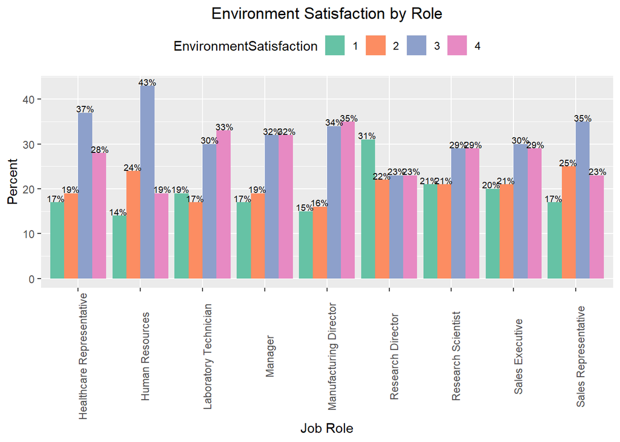

```r
#Plot Environment Satisfaction by Role
dfTrain.es <- dfTrain[,c("JobRole","EnvironmentSatisfaction")]
dfTrain3 <- makereadyforplot(dfTrain.es)

ggplot(data = dfTrain3, aes(x = factor(JobRole), y=Freq, group=EnvironmentSatisfaction, fill = EnvironmentSatisfaction)) +
  geom_bar(stat = "identity", position = "dodge") +
  xlab("Job Role") +
  ylab("Percent") +
  geom_text(size=2.5, vjust=-0.1, aes(label= paste(Freq,"%",sep="")), position=position_dodge(width=.95)) +
  scale_fill_brewer(palette = "Set2") +
  ggtitle("Environment Satisfaction by Role") +
  theme(legend.position="top",plot.title = element_text(hjust = 0.5),axis.text.x = element_text(angle = 90))
```

```r
#Welch's ANOVA for Environment Satisfaction
output.es.welch = welch.test(EnvironmentSatisfaction~JobRole,data=dfTrain.es)
```

```
  Welch's Heteroscedastic F Test
---------------------------------------------------------
  data : EnvironmentSatisfaction and JobRole

  statistic  : 1.31954
  num df     : 8
  denom df   : 301.3724
  p.value    : 0.233043

  Result     : Difference is not statistically significant.
---------------------------------------------------------
```

```r
#Fisher LSD with Bonferroni correction
aov.es = aov(EnvironmentSatisfaction~JobRole,data=dfTrain.es)
output.es.bon = LSD.test(aov.es,"JobRole", p.adj="bonferroni")
output.es.bon$groups
```

```
                          EnvironmentSatisfaction groups
Manufacturing Director                   2.896552      a
Manager                                  2.794872      a
Laboratory Technician                    2.774648      a
Healthcare Representative                2.752475      a
Sales Executive                          2.682171      a
Human Resources                          2.675676      a
Research Scientist                       2.663866      a
Sales Representative                     2.646154      a
Research Director                        2.390625      a
```

`[Chart 3: Environment Satisfaction Analytics]`

#### The mean relationship satisfaction for all job roles ranged from 2.50 to 2.77 [Chart 4]. Albeit at a p-value 0.9362, there is not sufficient evidence to suggest that the difference is statistically significant between the roles. Managers have the highest mean relationship satisfaction with 33% reported as Very High whereas Sales Representatives have the lowest mean with a reported 26% Low to and 28% High.

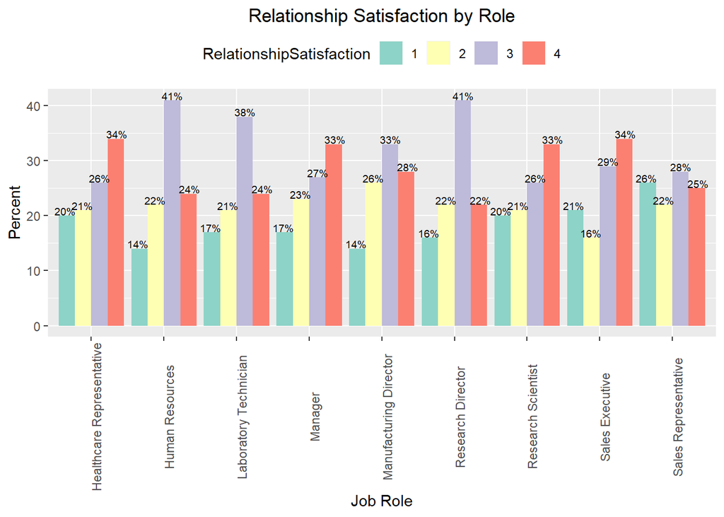

```r
#Plot Relationship Satisfaction by Role
dfTrain.rs <- dfTrain[,c("JobRole","RelationshipSatisfaction")]
dfTrain4 <- makereadyforplot(dfTrain.rs)

ggplot(data = dfTrain4, aes(x = factor(JobRole), y=Freq, group=RelationshipSatisfaction, fill = RelationshipSatisfaction)) +
  geom_bar(stat = "identity", position = "dodge") +
  xlab("Job Role") +
  ylab("Percent") +
  geom_text(size=2.5, vjust=-0.1, aes(label= paste(Freq,"%",sep="")), position=position_dodge(width=.95)) +
  scale_fill_brewer(palette = "Set3") +
  ggtitle("Relationship Satisfaction by Role") +
  theme(legend.position="top",plot.title = element_text(hjust = 0.5),axis.text.x = element_text(angle = 90))
```

```r
#Welch's ANOVA for Relationship Satisfaction
output.rs.welch = welch.test(RelationshipSatisfaction~JobRole,data=dfTrain.rs)
```

```
  Welch's Heteroscedastic F Test
---------------------------------------------------------
  data : RelationshipSatisfaction and JobRole

  statistic  : 0.3693834
  num df     : 8
  denom df   : 300.8832
  p.value    : 0.9362343

  Result     : Difference is not statistically significant.
---------------------------------------------------------
```

```r
#Fisher LSD with Bonferroni correction
aov.rs = aov(RelationshipSatisfaction~JobRole,data=dfTrain.rs)
output.rs.bon = LSD.test(aov.rs,"JobRole", p.adj="bonferroni")
output.rs.bon$groups
```

```
                          RelationshipSatisfaction groups
Manager                                   2.769231      a
Human Resources                           2.756757      a
Sales Executive                           2.755814      a
Manufacturing Director                    2.741379      a
Healthcare Representative                 2.732673      a
Research Scientist                        2.718487      a
Laboratory Technician                     2.694836      a
Research Director                         2.687500      a
Sales Representative                      2.507692      a
```

`[Chart 4: Relationship Satisfaction Analytics]`

#### Fifty-five percent (55%) or more of the survey responses within each job role suggest a better work life balance [Chart 5]. Human Resources personnel have the highest mean at 3.0 compared to Research Scientists with the lowest mean work life balance at 2.67. However, the p-value of 0.07 suggests that there may not be sufficient statistical evidence for its signifcance with the different roles.

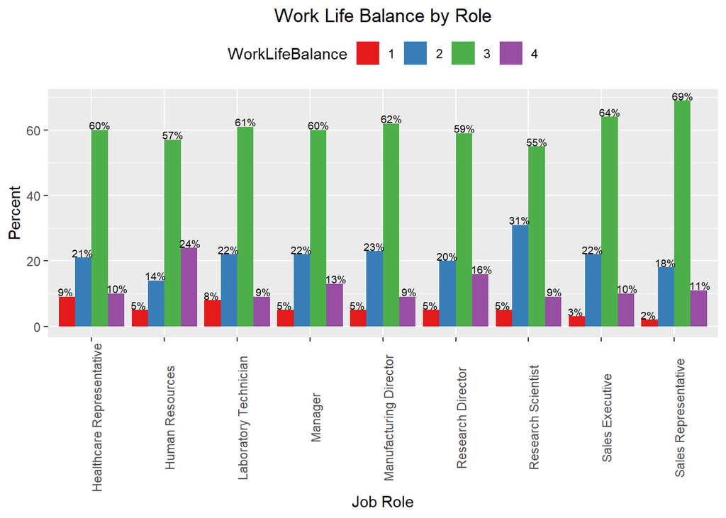

```r
#Plot Work Life Balance by Role
dfTrain.wlb <- dfTrain[,c("JobRole","WorkLifeBalance")]
dfTrain5 <- makereadyforplot(dfTrain.wlb)

ggplot(data = dfTrain5, aes(x = factor(JobRole), y=Freq, group=WorkLifeBalance, fill = WorkLifeBalance)) +
  geom_bar(stat = "identity", position = "dodge") +
  xlab("Job Role") +
  ylab("Percent") +
  geom_text(size=2.5, vjust=-0.1, aes(label= paste(Freq,"%",sep="")), position=position_dodge(width=.95)) +
  scale_fill_brewer(palette = "Set1") +
  ggtitle("Work Life Balance by Role") +
  theme(legend.position="top",plot.title = element_text(hjust = 0.5),axis.text.x = element_text(angle = 90))
```

```r
#Welch's ANOVA for Work Life Balance Satisfaction
output.wlb.welch = welch.test(WorkLifeBalance~JobRole,data=dfTrain.wlb)
```

```
  Welch's Heteroscedastic F Test
---------------------------------------------------------
  data : WorkLifeBalance and JobRole

  statistic  : 1.818854
  num df     : 8
  denom df   : 298.9337
  p.value    : 0.07310069

  Result     : Difference is not statistically significant.
---------------------------------------------------------
```

```r
#Fisher LSD with Bonferroni correction
aov.wlb = aov(WorkLifeBalance~JobRole,data=dfTrain.wlb)
output.wlb.bon = LSD.test(aov.wlb,"JobRole", p.adj="bonferroni")
output.wlb.bon$groups
```

```
                          WorkLifeBalance groups
Human Resources                  3.000000      a
Sales Representative             2.892308      a
Research Director                2.859375      a
Sales Executive                  2.810078      a
Manager                          2.807692      a
Manufacturing Director           2.758621      a
Laboratory Technician            2.713615      a
Healthcare Representative        2.712871      a
Research Scientist               2.668067      a
```

`[Chart 5: Work-Live Balance Analytics]`

```r
#----------------------------------KNN 2.0-----------------------------
#JobInvolvement + OverTime + MaritalStatus + JobRole + NumCompaniesWorked
dfTrain.knn <- dfTrain[,c(3,15,17,19,22,23)]
knn.model <- caret::train(Attrition ~ ., data = dfTrain.knn, method = "knn", preProcess = c("center", "scale"))
knn.pred <- predict(knn.model, newdata = dfVal)

knn.mat <- confusionMatrix(table(dfVal$Attrition, knn.pred))
aaaa <- data.frame(knn.mat$overall[1],knn.mat$byClass[2],knn.mat$byClass[1])
row.names(aaaa) <- NULL
names(aaaa) <- c("Accuracy", "Specificity", "Sensitivity")
aaaa
```

```
  Accuracy Specificity Sensitivity
1     0.84   0.5454545   0.8512111
```

`[Chart 6: kNN Modeling]`

## Prediction Conclusion

#### With an 87.3% overall accuracy [Chart 7], our custom logistic regression model identified that business travel, commute distance, environment satisfaction, job involvement, job role, job satisfaction, marital status, number of companies worked, overtime, and relationship satisfaction are factors that contribute to attrition. For a less complex model, we evaluated both a logistic regression with 85% accuracy [Chart 7] and a kNN model with 84% accuracy [Chart 6]. These models contains half the number of terms (five): job involvement, overtime, marital status, job role, and number of companies worked for. Managing these factors in developing and retaining employees could reduce and prevent attrition.

```r
#Sets the reference level to 'No' so that it is predicting 'Yes'
dfTrain$Attrition <- relevel(dfTrain$Attrition, ref = "No")
dfVal$Attrition <- relevel(dfVal$Attrition, ref = "No")

#Creates the prediction and sets the values to Yes/No
predictyn <- function(fit, test)
{
  p1 <- ifelse(predict(fit, test, type="response") > 0.5, "Yes", "No")
  p1
}

#-------------Cross Validation------------------
set.seed(1)
#train_perc <- 0.5
#samplesize <- length(dfTrain$Attrition)
#train_indices = sample(seq(1, samplesize,length = samplesize), train_perc*samplesize)
#dfTrain.train <- dfTrain[train_indices,]
#dfTrain.test <- dfTrain[-train_indices,]

#--------------------All of the variable names------------
#Age + BusinessTravel + DailyRate + Department + DistanceFromHome + Education + EducationField + EmployeeCount + EnvironmentSatisfaction + Gender + HourlyRate + JobInvolvement + JobLevel + JobRole + JobSatisfaction + MaritalStatus + MonthlyIncome + MonthlyRate + NumCompaniesWorked + OverTime + PercentSalaryHike + PerformanceRating + RelationshipSatisfaction + StandardHours + StockOptionLevel + TotalWorkingYears + TrainingTimesLastYear + WorkLifeBalance + YearsAtCompany + YearsInCurrentRole + YearsSinceLastPromotion + YearsWithCurrManager

#Determined the following variables to be unnecessary in the model:
#ID, EmployeeNumber, Over18, Rand, StandardHours, EmployeeCount

#Aparently we are no longer splitting up the data forcross validation
dfTrain.train <- dfTrain
dfTrain.test <- dfVal

#Automatically selecting explanatory variables
full.model <- glm(Attrition~., data = dfTrain.train, family="binomial")

#Stepwise
step.model <- stepAIC(full.model, direction = c("both"), trace=FALSE)

#Backward
back.model <- stepAIC(full.model, direction = c("backward"), trace=FALSE)

#Forward
forw.model <- stepAIC(full.model, direction = c("forward"), trace=FALSE)

#Custom Attrition w/Acc 86
#cust.model <- glm(Attrition~BusinessTravel + DistanceFromHome + EnvironmentSatisfaction + JobInvolvement + JobSatisfaction + MaritalStatus + NumCompaniesWorked + OverTime + TotalWorkingYears + WorkLifeBalance + YearsInCurrentRole + YearsSinceLastPromotion, data = dfTrain.train, family="binomial")

#Custom Attrition w/Acc 87.3%
cust.model <- glm(Attrition~BusinessTravel + DistanceFromHome + EnvironmentSatisfaction + JobInvolvement + JobRole + JobSatisfaction + MaritalStatus + NumCompaniesWorked + OverTime + RelationshipSatisfaction, data = dfTrain.train, family="binomial")

#Custom Attrition w/Acc 85%
cust2.model <- glm(Attrition~JobInvolvement + OverTime + MaritalStatus + JobRole + NumCompaniesWorked, data = dfTrain.train, family="binomial")

#Tests the models
#'WARNING: prediction from a rank-deficient fit may be misleading' suggest that we have too many explanatory variables
pred.cust <- as.vector(predictyn(cust.model, dfTrain.test))
pred.cust2 <- as.vector(predictyn(cust2.model, dfTrain.test))
pred.step <- as.vector(predictyn(step.model, dfTrain.test))
pred.back <- as.vector(predictyn(back.model, dfTrain.test))
pred.forw <- as.vector(predictyn(forw.model, dfTrain.test))

#Creates the confusion matrix with all those stats
cust.mat <- confusionMatrix(table(dfTrain.test$Attrition, pred.cust))
cust2.mat <- confusionMatrix(table(dfTrain.test$Attrition, pred.cust2))
step.mat <- confusionMatrix(table(dfTrain.test$Attrition, pred.step))
back.mat <- confusionMatrix(table(dfTrain.test$Attrition, pred.back))
forw.mat <- confusionMatrix(table(dfTrain.test$Attrition, pred.forw))

#cust.mat
#cust2.mat
#step.mat
#back.mat
#forw.mat
#knn.mat

#Prints out just the overall accuracy % of the models
acc <- as.data.frame(cbind(cust.mat$overall[1]*100, cust2.mat$overall[1]*100, step.mat$overall[1]*100, back.mat$overall[1]*100, forw.mat$overall[1]*100))
names(acc) <- c("Custom", "Custom 2", "Stepwise", "Backward", "Forward")

numvar <- as.data.frame(cbind( (length(names(cust.model$model))-1), (length(names(cust2.model$model))-1), (length(names(step.model$model))-1), (length(names(back.model$model))-1), (length(names(forw.model$model))-1)))
names(numvar) <- c("Custom", "Custom 2", "Stepwise", "Backward", "Forward")

spec <- as.data.frame(cbind(cust.mat$byClass[1]*100, cust2.mat$byClass[1]*100, step.mat$byClass[1]*100, back.mat$byClass[1]*100, forw.mat$byClass[1]*100))
names(spec) <- c("Custom", "Custom 2", "Stepwise", "Backward", "Forward")

sens <- as.data.frame(cbind(cust.mat$byClass[2]*100, cust2.mat$byClass[2]*100, step.mat$byClass[2]*100, back.mat$byClass[2]*100, forw.mat$byClass[2]*100))
names(sens) <- c("Custom", "Custom 2", "Stepwise", "Backward", "Forward")

model.info <- rbind(acc, sens, spec, numvar)

rownames(model.info) <- c("Accuracy", "Specificity", "Sensitivity", "Num Terms")
model.info
```

```
              Custom Custom 2 Stepwise Backward  Forward
Accuracy    87.33333 85.00000 87.33333 87.33333 86.33333
Specificity 78.94737 70.00000 76.19048 76.19048 68.18182
Sensitivity 87.90036 85.51724 88.17204 88.17204 87.76978
Num Terms   10.00000  5.00000 19.00000 19.00000 35.00000
```

`[Chart 7: Accuracy and #Terms]`

```r
#---------------Choose the best prediction and write to file--------------
#The custom model predictions for the file
dfPreds <- as.data.frame( cbind( dfVal$ID, pred.cust ) )
names(dfPreds) <- c("ID", "Attrition")

write.csv(dfPreds, "Case2PredictionsGillTran.csv", row.names = FALSE)
```